# Lab 08 - Text Mining

```r
knitr::opts_chunk$set(eval = T, include  = T)
```

# Learning goals

- Use `unnest_tokens()` and `unnest_ngrams()` to extract tokens and ngrams from text.
- Use dplyr and ggplot2 to analyze text data

# Lab description

For this lab we will be working with the medical record transcriptions from https://www.mtsamples.com/. And is loaded and “fairly” cleaned at https://github.com/JSC370/jsc370-2022/blob/main/data/medical_transcriptions/mtsamples.csv.

This markdown document should be rendered using `github_document` document.

### Setup packages

You should load in `dplyr`, (or `data.table` if you want to work that way), `ggplot2` and `tidytext`. If you don’t already have `tidytext` then you can install with

```r
install.packages("tidytext")
```

### read in Medical Transcriptions

Loading in reference transcription samples from https://www.mtsamples.com/

```r
library(tidytext)
library(readr)
library(dplyr)
library(tidyr)
library(ggplot2)
library(wordcloud)
library(kableExtra)


mt_samples <- read_csv("https://raw.githubusercontent.com/jeffreyz374/JSC370-Labs-And-Assignments/main/data/mtsamples.csv")
mt_samples <- mt_samples %>%
  select(description, medical_specialty, transcription)

head(mt_samples) %>%
  kable() %>%
  kable_styling()
```

description

medical_specialty

transcription

A 23-year-old white female presents with complaint of allergies.

Allergy / Immunology

SUBJECTIVE:, This 23-year-old white female presents with complaint of allergies. She used to have allergies when she lived in Seattle but she thinks they are worse here. In the past, she has tried Claritin, and Zyrtec. Both worked for short time but then seemed to lose effectiveness. She has used Allegra also. She used that last summer and she began using it again two weeks ago. It does not appear to be working very well. She has used over-the-counter sprays but no prescription nasal sprays. She does have asthma but doest not require daily medication for this and does not think it is flaring up.,MEDICATIONS: , Her only medication currently is Ortho Tri-Cyclen and the Allegra.,ALLERGIES: , She has no known medicine allergies.,OBJECTIVE:,Vitals: Weight was 130 pounds and blood pressure 124/78.,HEENT: Her throat was mildly erythematous without exudate. Nasal mucosa was erythematous and swollen. Only clear drainage was seen. TMs were clear.,Neck: Supple without adenopathy.,Lungs: Clear.,ASSESSMENT:, Allergic rhinitis.,PLAN:,1. She will try Zyrtec instead of Allegra again. Another option will be to use loratadine. She does not think she has prescription coverage so that might be cheaper.,2. Samples of Nasonex two sprays in each nostril given for three weeks. A prescription was written as well.

Consult for laparoscopic gastric bypass.

Bariatrics

PAST MEDICAL HISTORY:, He has difficulty climbing stairs, difficulty with airline seats, tying shoes, used to public seating, and lifting objects off the floor. He exercises three times a week at home and does cardio. He has difficulty walking two blocks or five flights of stairs. Difficulty with snoring. He has muscle and joint pains including knee pain, back pain, foot and ankle pain, and swelling. He has gastroesophageal reflux disease.,PAST SURGICAL HISTORY:, Includes reconstructive surgery on his right hand 13 years ago. ,SOCIAL HISTORY:, He is currently single. He has about ten drinks a year. He had smoked significantly up until several months ago. He now smokes less than three cigarettes a day.,FAMILY HISTORY:, Heart disease in both grandfathers, grandmother with stroke, and a grandmother with diabetes. Denies obesity and hypertension in other family members.,CURRENT MEDICATIONS:, None.,ALLERGIES:, He is allergic to Penicillin.,MISCELLANEOUS/EATING HISTORY:, He has been going to support groups for seven months with Lynn Holmberg in Greenwich and he is from Eastchester, New York and he feels that we are the appropriate program. He had a poor experience with the Greenwich program. Eating history, he is not an emotional eater. Does not like sweets. He likes big portions and carbohydrates. He likes chicken and not steak. He currently weighs 312 pounds. Ideal body weight would be 170 pounds. He is 142 pounds overweight. If ,he lost 60% of his excess body weight that would be 84 pounds and he should weigh about 228.,REVIEW OF SYSTEMS: ,Negative for head, neck, heart, lungs, GI, GU, orthopedic, and skin. Specifically denies chest pain, heart attack, coronary artery disease, congestive heart failure, arrhythmia, atrial fibrillation, pacemaker, high cholesterol, pulmonary embolism, high blood pressure, CVA, venous insufficiency, thrombophlebitis, asthma, shortness of breath, COPD, emphysema, sleep apnea, diabetes, leg and foot swelling, osteoarthritis, rheumatoid arthritis, hiatal hernia, peptic ulcer disease, gallstones, infected gallbladder, pancreatitis, fatty liver, hepatitis, hemorrhoids, rectal bleeding, polyps, incontinence of stool, urinary stress incontinence, or cancer. Denies cellulitis, pseudotumor cerebri, meningitis, or encephalitis.,PHYSICAL EXAMINATION:, He is alert and oriented x 3. Cranial nerves II-XII are intact. Afebrile. Vital Signs are stable.

Consult for laparoscopic gastric bypass.

Bariatrics

HISTORY OF PRESENT ILLNESS: , I have seen ABC today. He is a very pleasant gentleman who is 42 years old, 344 pounds. He is 5’9”. He has a BMI of 51. He has been overweight for ten years since the age of 33, at his highest he was 358 pounds, at his lowest 260. He is pursuing surgical attempts of weight loss to feel good, get healthy, and begin to exercise again. He wants to be able to exercise and play volleyball. Physically, he is sluggish. He gets tired quickly. He does not go out often. When he loses weight he always regains it and he gains back more than he lost. His biggest weight loss is 25 pounds and it was three months before he gained it back. He did six months of not drinking alcohol and not taking in many calories. He has been on multiple commercial weight loss programs including Slim Fast for one month one year ago and Atkin’s Diet for one month two years ago.,PAST MEDICAL HISTORY: , He has difficulty climbing stairs, difficulty with airline seats, tying shoes, used to public seating, difficulty walking, high cholesterol, and high blood pressure. He has asthma and difficulty walking two blocks or going eight to ten steps. He has sleep apnea and snoring. He is a diabetic, on medication. He has joint pain, knee pain, back pain, foot and ankle pain, leg and foot swelling. He has hemorrhoids.,PAST SURGICAL HISTORY: , Includes orthopedic or knee surgery.,SOCIAL HISTORY: , He is currently single. He drinks alcohol ten to twelve drinks a week, but does not drink five days a week and then will binge drink. He smokes one and a half pack a day for 15 years, but he has recently stopped smoking for the past two weeks.,FAMILY HISTORY: , Obesity, heart disease, and diabetes. Family history is negative for hypertension and stroke.,CURRENT MEDICATIONS:, Include Diovan, Crestor, and Tricor.,MISCELLANEOUS/EATING HISTORY: ,He says a couple of friends of his have had heart attacks and have had died. He used to drink everyday, but stopped two years ago. He now only drinks on weekends. He is on his second week of Chantix, which is a medication to come off smoking completely. Eating, he eats bad food. He is single. He eats things like bacon, eggs, and cheese, cheeseburgers, fast food, eats four times a day, seven in the morning, at noon, 9 p.m., and 2 a.m. He currently weighs 344 pounds and 5’9”. His ideal body weight is 160 pounds. He is 184 pounds overweight. If he lost 70% of his excess body weight that would be 129 pounds and that would get him down to 215.,REVIEW OF SYSTEMS: , Negative for head, neck, heart, lungs, GI, GU, orthopedic, or skin. He also is positive for gout. He denies chest pain, heart attack, coronary artery disease, congestive heart failure, arrhythmia, atrial fibrillation, pacemaker, pulmonary embolism, or CVA. He denies venous insufficiency or thrombophlebitis. Denies shortness of breath, COPD, or emphysema. Denies thyroid problems, hip pain, osteoarthritis, rheumatoid arthritis, GERD, hiatal hernia, peptic ulcer disease, gallstones, infected gallbladder, pancreatitis, fatty liver, hepatitis, rectal bleeding, polyps, incontinence of stool, urinary stress incontinence, or cancer. He denies cellulitis, pseudotumor cerebri, meningitis, or encephalitis.,PHYSICAL EXAMINATION: ,He is alert and oriented x 3. Cranial nerves II-XII are intact. Neck is soft and supple. Lungs: He has positive wheezing bilaterally. Heart is regular rhythm and rate. His abdomen is soft. Extremities: He has 1+ pitting edema.,IMPRESSION/PLAN:, I have explained to him the risks and potential complications of laparoscopic gastric bypass in detail and these include bleeding, infection, deep venous thrombosis, pulmonary embolism, leakage from the gastrojejuno-anastomosis, jejunojejuno-anastomosis, and possible bowel obstruction among other potential complications. He understands. He wants to proceed with workup and evaluation for laparoscopic Roux-en-Y gastric bypass. He will need to get a letter of approval from Dr. XYZ. He will need to see a nutritionist and mental health worker. He will need an upper endoscopy by either Dr. XYZ. He will need to go to Dr. XYZ as he previously had a sleep study. We will need another sleep study. He will need H. pylori testing, thyroid function tests, LFTs, glycosylated hemoglobin, and fasting blood sugar. After this is performed, we will submit him for insurance approval.

2-D M-Mode. Doppler.

Cardiovascular / Pulmonary

2-D M-MODE: , ,1. Left atrial enlargement with left atrial diameter of 4.7 cm.,2. Normal size right and left ventricle.,3. Normal LV systolic function with left ventricular ejection fraction of 51%.,4. Normal LV diastolic function.,5. No pericardial effusion.,6. Normal morphology of aortic valve, mitral valve, tricuspid valve, and pulmonary valve.,7. PA systolic pressure is 36 mmHg.,DOPPLER: , ,1. Mild mitral and tricuspid regurgitation.,2. Trace aortic and pulmonary regurgitation.

2-D Echocardiogram

Cardiovascular / Pulmonary

1. The left ventricular cavity size and wall thickness appear normal. The wall motion and left ventricular systolic function appears hyperdynamic with estimated ejection fraction of 70% to 75%. There is near-cavity obliteration seen. There also appears to be increased left ventricular outflow tract gradient at the mid cavity level consistent with hyperdynamic left ventricular systolic function. There is abnormal left ventricular relaxation pattern seen as well as elevated left atrial pressures seen by Doppler examination.,2. The left atrium appears mildly dilated.,3. The right atrium and right ventricle appear normal.,4. The aortic root appears normal.,5. The aortic valve appears calcified with mild aortic valve stenosis, calculated aortic valve area is 1.3 cm square with a maximum instantaneous gradient of 34 and a mean gradient of 19 mm.,6. There is mitral annular calcification extending to leaflets and supportive structures with thickening of mitral valve leaflets with mild mitral regurgitation.,7. The tricuspid valve appears normal with trace tricuspid regurgitation with moderate pulmonary artery hypertension. Estimated pulmonary artery systolic pressure is 49 mmHg. Estimated right atrial pressure of 10 mmHg.,8. The pulmonary valve appears normal with trace pulmonary insufficiency.,9. There is no pericardial effusion or intracardiac mass seen.,10. There is a color Doppler suggestive of a patent foramen ovale with lipomatous hypertrophy of the interatrial septum.,11. The study was somewhat technically limited and hence subtle abnormalities could be missed from the study.,

Morbid obesity. Laparoscopic antecolic antegastric Roux-en-Y gastric bypass with EEA anastomosis. This is a 30-year-old female, who has been overweight for many years. She has tried many different diets, but is unsuccessful.

Bariatrics

PREOPERATIVE DIAGNOSIS: , Morbid obesity.,POSTOPERATIVE DIAGNOSIS: ,Morbid obesity.,PROCEDURE: , Laparoscopic antecolic antegastric Roux-en-Y gastric bypass with EEA anastomosis.,ANESTHESIA: , General with endotracheal intubation.,INDICATION FOR PROCEDURE: , This is a 30-year-old female, who has been overweight for many years. She has tried many different diets, but is unsuccessful. She has been to our Bariatric Surgery Seminar, received some handouts, and signed the consent. The risks and benefits of the procedure have been explained to the patient.,PROCEDURE IN DETAIL: ,The patient was taken to the operating room and placed supine on the operating room table. All pressure points were carefully padded. She was given general anesthesia with endotracheal intubation. SCD stockings were placed on both legs. Foley catheter was placed for bladder decompression. The abdomen was then prepped and draped in standard sterile surgical fashion. Marcaine was then injected through umbilicus. A small incision was made. A Veress needle was introduced into the abdomen. CO2 insufflation was done to a maximum pressure of 15 mmHg. A 12-mm VersaStep port was placed through the umbilicus. I then placed a 5-mm port just anterior to the midaxillary line and just subcostal on the right side. I placed another 5-mm port in the midclavicular line just subcostal on the right side, a few centimeters below and medial to that, I placed a 12-mm VersaStep port. On the left side, just anterior to the midaxillary line and just subcostal, I placed a 5-mm port. A few centimeters below and medial to that, I placed a 15-mm port. I began by lifting up the omentum and identifying the transverse colon and lifting that up and thereby identifying my ligament of Treitz. I ran the small bowel down approximately 40 cm and divided the small bowel with a white load GIA stapler. I then divided the mesentery all the way down to the base of the mesentery with a LigaSure device. I then ran the distal bowel down, approximately 100 cm, and at 100 cm, I made a hole at the antimesenteric portion of the Roux limb and a hole in the antimesenteric portion of the duodenogastric limb, and I passed a 45 white load stapler and fired a stapler creating a side-to-side anastomosis. I reapproximated the edges of the defect. I lifted it up and stapled across it with another white load stapler. I then closed the mesenteric defect with interrupted Surgidac sutures. I divided the omentum all the way down to the colon in order to create a passageway for my small bowel to go antecolic. I then put the patient in reverse Trendelenburg. I placed a liver retractor, identified, and dissected the angle of His. I then dissected on the lesser curve, approximately 2.5 cm below the gastroesophageal junction, and got into a lesser space. I fired transversely across the stomach with a 45 blue load stapler. I then used two fires of the 60 blue load with SeamGuard to go up into my angle of His, thereby creating my gastric pouch. I then made a hole at the base of the gastric pouch and had Anesthesia remove the bougie and place the OG tube connected to the anvil. I pulled the anvil into place, and I then opened up my 15-mm port site and passed my EEA stapler. I passed that in the end of my Roux limb and had the spike come out antimesenteric. I joined the spike with the anvil and fired a stapler creating an end-to-side anastomosis, then divided across the redundant portion of my Roux limb with a white load GI stapler, and removed it with an Endocatch bag. I put some additional 2-0 Vicryl sutures in the anastomosis for further security. I then placed a bowel clamp across the bowel. I went above and passed an EGD scope into the mouth down to the esophagus and into the gastric pouch. I distended gastric pouch with air. There was no air leak seen. I could pass the scope easily through the anastomosis. There was no bleeding seen through the scope. We closed the 15-mm port site with interrupted 0 Vicryl suture utilizing Carter-Thomason. I copiously irrigated out that incision with about 2 L of saline. I then closed the skin of all incisions with running Monocryl. Sponge, instrument, and needle counts were correct at the end of the case. The patient tolerated the procedure well without any complications.

## Question 1: What specialties do we have?

We can use `count()` from `dplyr` to figure out how many different catagories do we have? Are these catagories related? overlapping? evenly distributed?

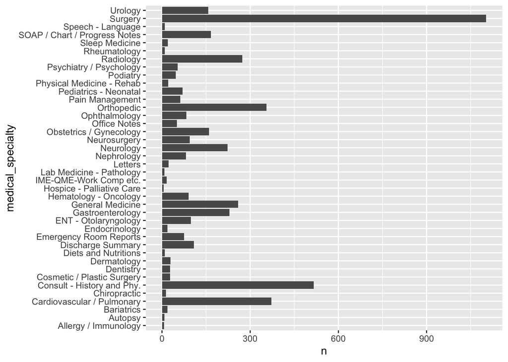

```r
mt_samples %>%
  count(medical_specialty, sort = TRUE) %>%
  ggplot(aes(medical_specialty, n)) +
  geom_col() +
  coord_flip()
```

## Question 2

- Tokenize the the words in the `transcription` column
- Count the number of times each token appears
- Visualize the top 20 most frequent words

```r
tokens <- mt_samples %>%
  select(transcription) %>%
  unnest_tokens(word, transcription) %>%
  group_by(word) %>%
  summarise(word_frequency = n()) %>%
  arrange(across(word_frequency, desc)) %>%
  head(20)

tokens %>%
  kable() %>%
  kable_styling()
```

| word | word_frequency |
| --- | --- |
| the | 149888 |
| and | 82779 |
| was | 71765 |
| of | 59205 |
| to | 50632 |
| a | 42810 |
| with | 35815 |
| in | 32807 |
| is | 26378 |
| patient | 22065 |
| no | 17874 |
| she | 17593 |
| for | 17049 |
| he | 15542 |
| were | 15535 |
| on | 14694 |
| this | 13949 |
| at | 13492 |
| then | 12430 |
| right | 11587 |

Above, we can see the top 20 words and their associated frequencies. Next, we will draw a barplot describing these frequencies:

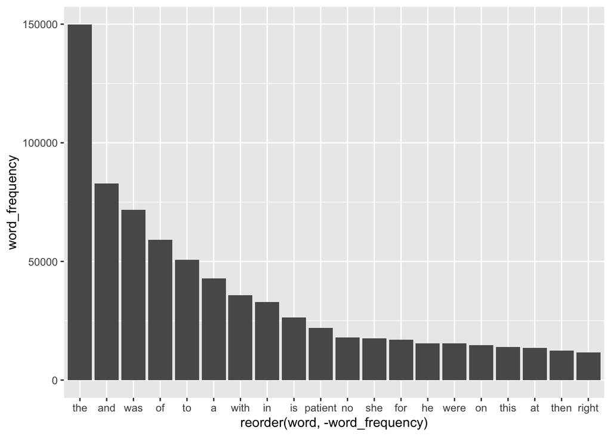

```r
tokens %>%
  ggplot(aes(reorder(word, -word_frequency), word_frequency)) +
  geom_bar(stat = 'identity')
```

We can also draw a (currently not so interesting) Wordcloud visualization of these words:

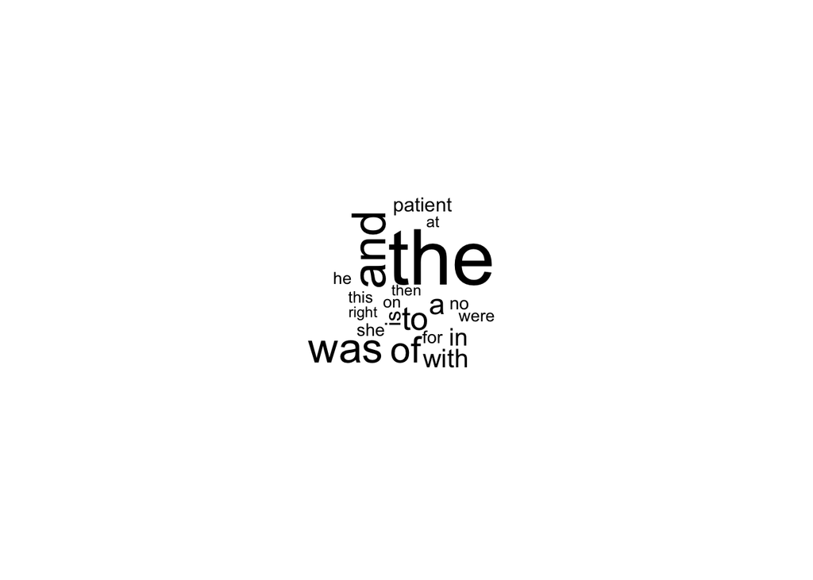

```r
wordcloud(tokens$word, tokens$word_frequency)
```

Explain what we see from this result. Does it makes sense? What insights (if any) do we get?

The results we get from tokenizing make sense as words such as the, and, was, and so on are typically assumed to be frequently occurring in English medical journals. However, we don’t gain much insight from this as knowing these regular English words are the most prevalent doesn’t tell us much about the contents of these journals, the categories to which they belong, or frankly any other useful information.

## Question 3

- Redo visualization but remove stopwords before
- Bonus points if you remove numbers as well

```r
tokens <- mt_samples %>%
  select(transcription) %>%
  unnest_tokens(word, transcription) %>%
  anti_join(stop_words, by="word") %>%
  subset(!grepl("^\\d+$", word)) %>%
  group_by(word) %>%
  summarise(word_frequency = n()) %>%
  arrange(across(word_frequency, desc)) %>%
  head(20)

tokens %>%
  kable() %>%
  kable_styling()
```

| word | word_frequency |
| --- | --- |
| patient | 22065 |
| left | 11258 |
| history | 9509 |
| normal | 7526 |
| procedure | 7463 |
| pain | 5976 |
| noted | 4348 |
| time | 4287 |
| mg | 4087 |
| blood | 3956 |
| performed | 3953 |
| skin | 3798 |
| anesthesia | 3707 |
| incision | 3601 |
| removed | 3532 |
| diagnosis | 3212 |
| artery | 3027 |
| anterior | 2932 |
| disease | 2682 |
| past | 2674 |

Above, we can see the top 20 words and their associated frequencies AFTER filtering out stopwords. Next, we will draw a barplot describing these frequencies:

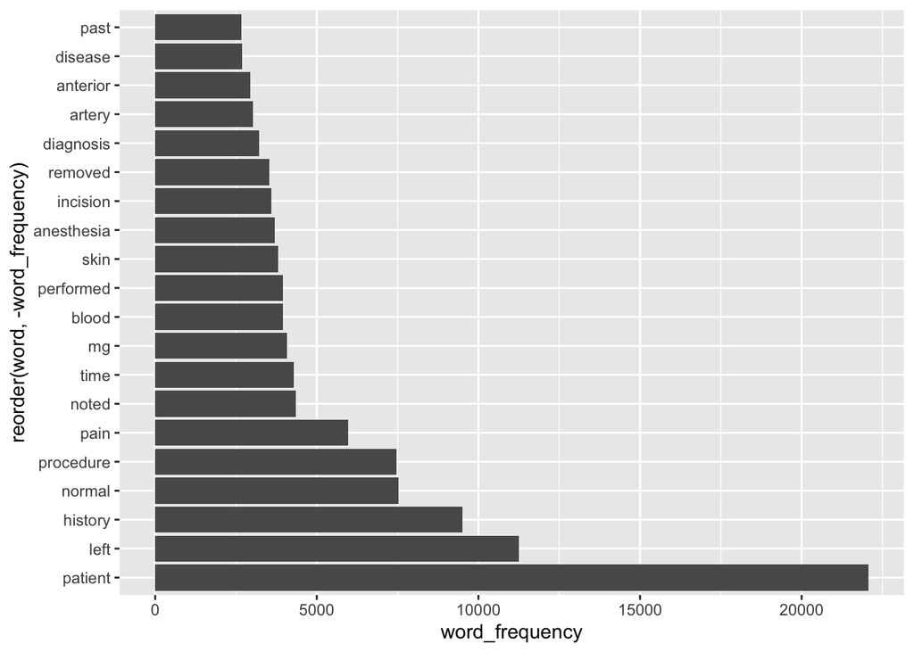

```r
tokens %>%
  ggplot(aes(reorder(word, -word_frequency), word_frequency)) +
  geom_bar(stat = 'identity') +
  coord_flip()
```

We can also draw a (now a little more interesting) Wordcloud visualization of these words:

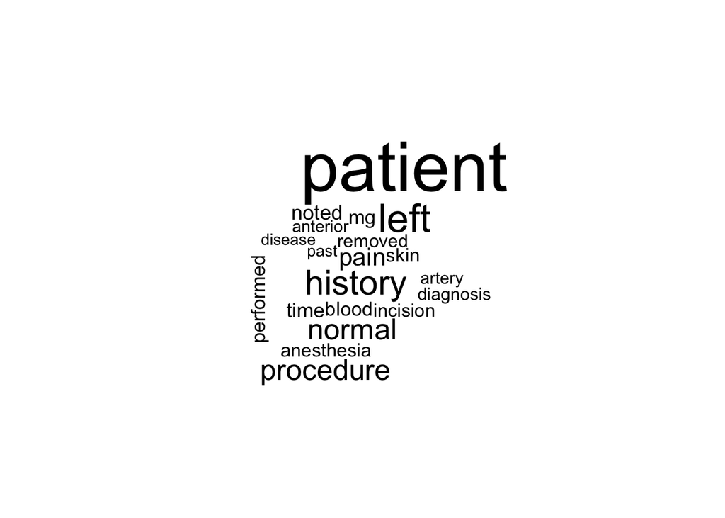

```r
wordcloud(tokens$word, tokens$word_frequency)
```

What do we see know that we have removed stop words? Does it give us a better idea of what the text is about?

By removing stopwords we can indeed start to see some more interesting results about what words appear the most frequently. That is, it is now a lot clearer that we are looking through medical journals with words such as “patient”, “procedure”, and “diagnosis” appearing very frequently.

# Question 4

Repeat question 2, but this time tokenize into bi-grams. How does the result change if you look at tri-grams?

We will first consider bigrams:

```r
tokens <- mt_samples %>%
  select(transcription) %>%
  unnest_tokens(bigram, transcription, token = "ngrams", n = 2) %>%
  group_by(bigram) %>%
  summarise(bigram_frequency = n()) %>%
  separate(bigram,
           c("word1", "word2"),
           extra = "drop",
           remove = FALSE,
           sep = " ",
           fill = "right") %>%
  anti_join(stop_words, by = c("word1" = "word")) %>%
  anti_join(stop_words, by = c("word2" = "word")) %>%
  subset(!grepl("\\d+", bigram)) %>%
  arrange(across(bigram_frequency, desc)) %>%
  head(20)

tokens %>%
  kable() %>%
  kable_styling()
```

| bigram | word1 | word2 | bigram_frequency |
| --- | --- | --- | --- |
| blood pressure | blood | pressure | 1265 |
| medical history | medical | history | 1223 |
| preoperative diagnosis | preoperative | diagnosis | 1176 |
| physical examination | physical | examination | 1156 |
| vital signs | vital | signs | 1121 |
| past medical | past | medical | 1113 |
| postoperative diagnosis | postoperative | diagnosis | 1092 |
| coronary artery | coronary | artery | 1032 |
| patient tolerated | patient | tolerated | 994 |
| blood loss | blood | loss | 965 |
| family history | family | history | 941 |
| social history | social | history | 865 |
| stable condition | stable | condition | 835 |
| supine position | supine | position | 786 |
| status post | status | post | 783 |
| estimated blood | estimated | blood | 754 |
| sterile fashion | sterile | fashion | 721 |
| mg p.o | mg | p.o | 718 |
| chest pain | chest | pain | 707 |
| informed consent | informed | consent | 685 |

Above, we can see the top 20 bigrams and their associated frequencies AFTER filtering out stopwords. Next, we will draw a barplot describing these frequencies:

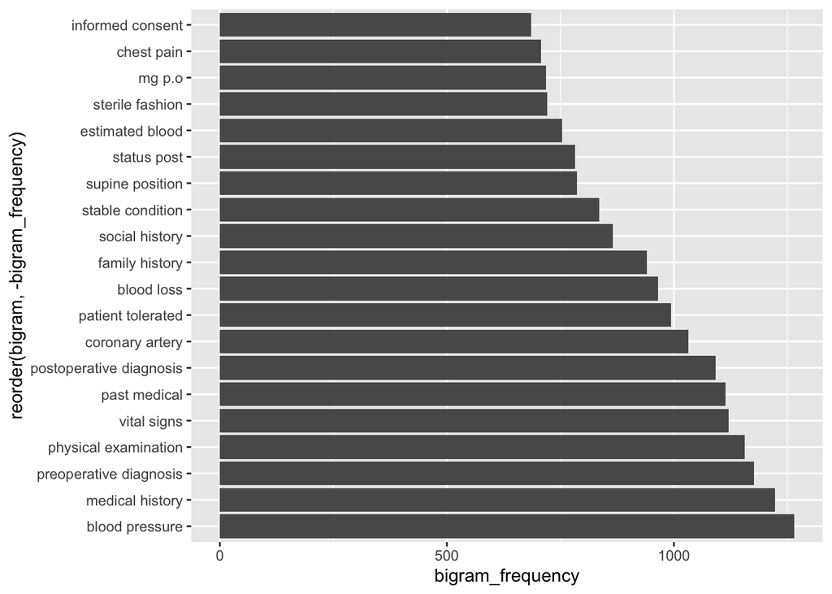

```r
tokens %>%
  ggplot(aes(reorder(bigram, -bigram_frequency), bigram_frequency)) +
  geom_bar(stat = 'identity') +
  coord_flip()
```

Now, we will do the exact same thing but with trigrams:

```r
tokens <- mt_samples %>%
  select(transcription) %>%
  unnest_tokens(trigram, transcription, token = "ngrams", n = 3) %>%
  group_by(trigram) %>%
  summarise(trigram_frequency = n()) %>%
  separate(trigram,
           c("word1", "word2", "word3"),
           extra = "drop",
           remove = FALSE,
           sep = " ",
           fill = "right") %>%
  anti_join(stop_words, by = c("word1" = "word")) %>%
  anti_join(stop_words, by = c("word2" = "word")) %>%
  anti_join(stop_words, by = c("word3" = "word")) %>%
  subset(!grepl("\\d+", trigram)) %>%
  arrange(across(trigram_frequency, desc)) %>%
  head(20)

tokens %>%
  kable() %>%
  kable_styling()
```

| trigram | word1 | word2 | word3 | trigram_frequency |
| --- | --- | --- | --- | --- |
| past medical history | past | medical | history | 1063 |
| estimated blood loss | estimated | blood | loss | 754 |
| coronary artery disease | coronary | artery | disease | 419 |
| past surgical history | past | surgical | history | 419 |
| examination vital signs | examination | vital | signs | 404 |
| physical examination vital | physical | examination | vital | 404 |
| usual sterile fashion | usual | sterile | fashion | 376 |
| mg p.o daily | mg | p.o | daily | 273 |
| left anterior descending | left | anterior | descending | 269 |
| left lower extremity | left | lower | extremity | 192 |
| heart regular rate | heart | regular | rate | 189 |
| blood loss minimal | blood | loss | minimal | 176 |
| abdomen soft nontender | abdomen | soft | nontender | 172 |
| vital signs blood | vital | signs | blood | 170 |
| congestive heart failure | congestive | heart | failure | 169 |
| signs blood pressure | signs | blood | pressure | 167 |
| normal sinus rhythm | normal | sinus | rhythm | 162 |
| cranial nerves ii | cranial | nerves | ii | 159 |
| transverse carpal ligament | transverse | carpal | ligament | 159 |
| vital signs temperature | vital | signs | temperature | 156 |

Above, we can see the top 20 trigrams and their associated frequencies AFTER filtering out stopwords. Next, we will draw a barplot describing these frequencies:

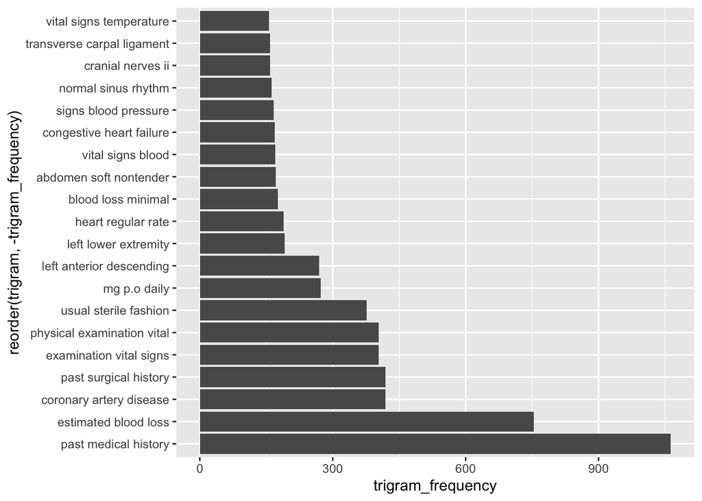

```r
tokens %>%
  ggplot(aes(reorder(trigram, -trigram_frequency), trigram_frequency)) +
  geom_bar(stat = 'identity') +
  coord_flip()
```

We can see that the results change somewhat after transitioning from bigrams to trigrams, which makes sense because chunks of 3 words will probably have different frequencies than chunks of 2 words. This could be for many reasons, such as some of the more frequent bigrams having a stop word immediately following (i.e. “blood loss of”), which would make the corresponding trigram ineligible to be included in our count.

# Question 5

Using the results you got from question 4. Pick a word and count the words that appears after and before it.

First, reset `tokens` to hold all the trigrams and not just the top 20:

```r
tokens <- mt_samples %>%
  select(transcription) %>%
  unnest_tokens(trigram, transcription, token = "ngrams", n = 3) %>%
  group_by(trigram) %>%
  summarise(trigram_frequency = n()) %>%
  separate(trigram,
           c("word1", "word2", "word3"),
           extra = "drop",
           remove = FALSE,
           sep = " ",
           fill = "right") %>%
  anti_join(stop_words, by = c("word1" = "word")) %>%
  anti_join(stop_words, by = c("word2" = "word")) %>%
  anti_join(stop_words, by = c("word3" = "word")) %>%
  subset(!grepl("\\d+", trigram)) %>%
  arrange(across(trigram_frequency, desc))
```

Then, we will look at which words appear the most frequently before the word “blood”:

```r
tokens %>%
  subset(word2 == "blood") %>%
  group_by(word1) %>%
  summarise(word1_freq = n()) %>%
  arrange(across(word1_freq, desc)) %>%
  head(20) %>%
  kable() %>%
  kable_styling()
```

| word1 | word1_freq |
| --- | --- |
| patient’s | 6 |
| low | 5 |
| arterial | 4 |
| cord | 4 |
| elevated | 4 |
| fasting | 4 |
| multiple | 4 |
| occult | 4 |
| cold | 3 |
| initial | 3 |
| normal | 3 |
| peripheral | 3 |
| white | 3 |
| additional | 2 |
| control | 2 |
| controlled | 2 |
| crp | 2 |
| detected | 2 |
| diagnosis | 2 |
| fever | 2 |

We can also visualize the frequencies:

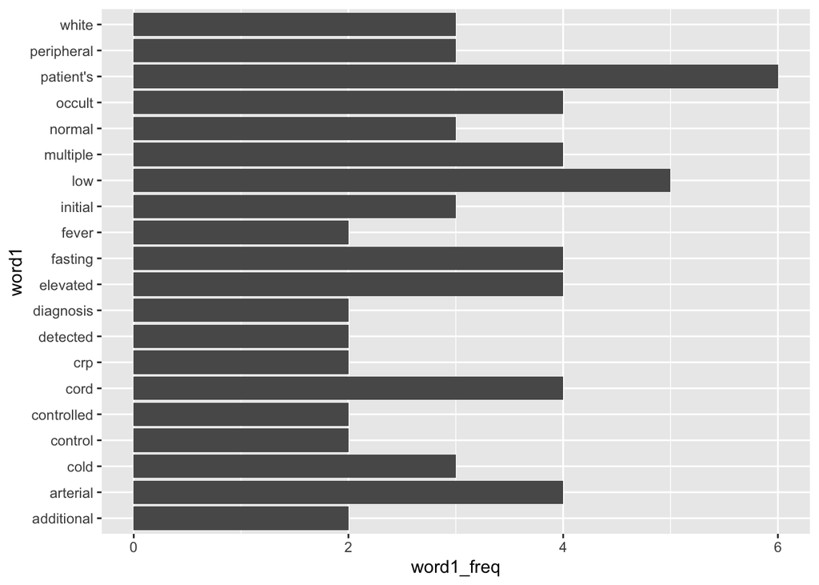

```r
tokens %>%
  subset(word2 == "blood") %>%
  group_by(word1) %>%
  summarise(word1_freq = n()) %>%
  arrange(across(word1_freq, desc)) %>%
  head(20) %>%
  ggplot(aes(word1, word1_freq)) +
  geom_bar(stat = 'identity') +
  coord_flip()
```

We can also look at which words appear the most frequently AFTER the word “blood”:

```r
tokens %>%
  subset(word2 == "blood") %>%
  group_by(word3) %>%
  summarise(word3_freq = n()) %>%
  arrange(across(word3_freq, desc)) %>%
  head(20) %>%
  kable() %>%
  kable_styling()
```

| word3 | word3_freq |
| --- | --- |
| pressure | 78 |
| loss | 38 |
| cultures | 13 |
| sugar | 13 |
| flow | 11 |
| sugars | 10 |
| pressures | 9 |
| culture | 7 |
| glucose | 6 |
| supply | 5 |
| tests | 5 |
| transfusions | 5 |
| count | 4 |
| return | 4 |
| test | 4 |
| vessels | 4 |
| cell | 3 |
| gas | 3 |
| studies | 3 |
| borne | 2 |

We can again visualize the frequencies:

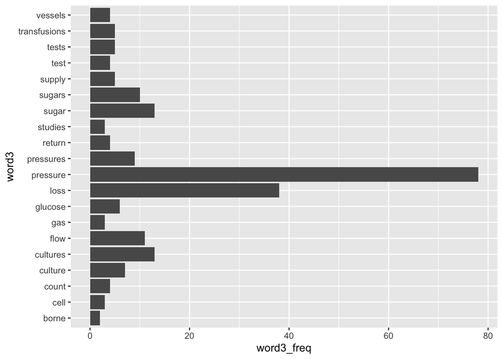

```r
tokens %>%
  subset(word2 == "blood") %>%
  group_by(word3) %>%
  summarise(word3_freq = n()) %>%
  arrange(across(word3_freq, desc)) %>%
  head(20) %>%
  ggplot(aes(word3, word3_freq)) +
  geom_bar(stat = 'identity') +
  coord_flip()
```

From the visualizations and frequency tables above, we can conclude that the word that most frequently appears before “blood” is “patient’s”, while the word that most frequently appears after “blood” is “pressure”.

# Question 6

Which words are most used in each of the specialties. you can use `group_by()` and `top_n()` from `dplyr` to have the calculations be done within each specialty. Remember to remove stopwords. How about the most 5 used words?

First, we will examine the top words used in each of the specialties:

```r
mt_samples %>%
  unnest_tokens(word, transcription) %>%
  anti_join(stop_words, by = "word") %>%
  subset(!grepl("^\\d+$", word)) %>%
  group_by(medical_specialty) %>%
  count(word, sort = TRUE) %>%
  top_n(1, n) %>%
  kable() %>%
  kable_styling()
```

| medical_specialty | word | n |
| --- | --- | --- |
| Surgery | patient | 4855 |
| Consult - History and Phy. | patient | 3046 |
| Orthopedic | patient | 1711 |
| Cardiovascular / Pulmonary | left | 1550 |
| General Medicine | patient | 1356 |
| Gastroenterology | patient | 872 |
| Urology | patient | 776 |
| Radiology | left | 701 |
| Emergency Room Reports | patient | 685 |
| Discharge Summary | patient | 672 |
| Neurology | left | 672 |
| Obstetrics / Gynecology | patient | 628 |
| SOAP / Chart / Progress Notes | patient | 537 |
| Psychiatry / Psychology | patient | 532 |
| Ophthalmology | eye | 456 |
| ENT - Otolaryngology | patient | 415 |
| Neurosurgery | patient | 374 |
| Nephrology | patient | 348 |
| Hematology - Oncology | patient | 316 |
| Pediatrics - Neonatal | patient | 247 |
| Pain Management | patient | 236 |
| Podiatry | foot | 232 |
| Office Notes | normal | 230 |
| Physical Medicine - Rehab | patient | 220 |
| Dentistry | patient | 195 |
| Chiropractic | pain | 187 |
| IME-QME-Work Comp etc. | pain | 152 |
| Sleep Medicine | sleep | 143 |
| Endocrinology | thyroid | 129 |
| Cosmetic / Plastic Surgery | patient | 116 |
| Speech - Language | patient | 105 |
| Dermatology | patient | 101 |
| Dermatology | skin | 101 |
| Autopsy | left | 83 |
| Letters | pain | 80 |
| Bariatrics | patient | 62 |
| Rheumatology | history | 50 |
| Diets and Nutritions | patient | 43 |
| Hospice - Palliative Care | patient | 43 |
| Allergy / Immunology | history | 38 |
| Lab Medicine - Pathology | cm | 35 |
| Lab Medicine - Pathology | tumor | 35 |

```r
mt_samples %>%
  unnest_tokens(word, transcription) %>%
  anti_join(stop_words, by = "word") %>%
  subset(!grepl("^\\d+$", word)) %>%
  group_by(medical_specialty) %>%
  count(word) %>%
  top_n(5, n) %>%
  kable() %>%
  kable_styling()
```

| medical_specialty | word | n |
| --- | --- | --- |
| Allergy / Immunology | allergies | 21 |
| Allergy / Immunology | history | 38 |
| Allergy / Immunology | nasal | 13 |
| Allergy / Immunology | noted | 23 |
| Allergy / Immunology | past | 13 |
| Allergy / Immunology | patient | 22 |
| Autopsy | anterior | 47 |
| Autopsy | body | 40 |
| Autopsy | inch | 59 |
| Autopsy | left | 83 |
| Autopsy | neck | 55 |
| Bariatrics | gastric | 30 |
| Bariatrics | history | 50 |
| Bariatrics | patient | 62 |
| Bariatrics | surgery | 34 |
| Bariatrics | weight | 36 |
| Cardiovascular / Pulmonary | artery | 1085 |
| Cardiovascular / Pulmonary | coronary | 681 |
| Cardiovascular / Pulmonary | history | 654 |
| Cardiovascular / Pulmonary | left | 1550 |
| Cardiovascular / Pulmonary | patient | 1516 |
| Chiropractic | dr | 66 |
| Chiropractic | history | 56 |
| Chiropractic | left | 54 |
| Chiropractic | pain | 187 |
| Chiropractic | patient | 85 |
| Consult - History and Phy. | history | 2820 |
| Consult - History and Phy. | mg | 908 |
| Consult - History and Phy. | normal | 1368 |
| Consult - History and Phy. | pain | 1153 |

[output cut: 180 more lines]

# Question 7 - extra

Find your own insight in the data:

Ideas:

- Interesting ngrams
- See if certain words are used more in some specialties then others

We want to find out what pentagrams appear the most frequently AFTER removing stopwords:

```r
tokens <- mt_samples %>%
  select(transcription) %>%
  unnest_tokens(pentagram, transcription, token = "ngrams", n = 5) %>%
  group_by(pentagram) %>%
  summarise(pentagram_frequency = n()) %>%
  separate(pentagram,
           c("word1", "word2", "word3", "word4", "word5"),
           extra = "drop",
           remove = FALSE,
           sep = " ",
           fill = "right") %>%
  anti_join(stop_words, by = c("word1" = "word")) %>%
  anti_join(stop_words, by = c("word2" = "word")) %>%
  anti_join(stop_words, by = c("word3" = "word")) %>%
  anti_join(stop_words, by = c("word4" = "word")) %>%
  anti_join(stop_words, by = c("word5" = "word")) %>%
  subset(!grepl("\\d+", pentagram)) %>%
  arrange(across(pentagram_frequency, desc)) %>%
  head(20)

tokens %>%
  kable() %>%
  kable_styling()
```

| pentagram | word1 | word2 | word3 | word4 | word5 | pentagram_frequency |
| --- | --- | --- | --- | --- | --- | --- |
| physical examination vital signs temperature | physical | examination | vital | signs | temperature | 89 |
| examination vital signs blood pressure | examination | vital | signs | blood | pressure | 59 |
| physical examination vital signs blood | physical | examination | vital | signs | blood | 59 |
| NA | NA | NA | NA | NA | NA | 53 |
| physical examination vital signs pulse | physical | examination | vital | signs | pulse | 48 |
| coronary artery disease status post | coronary | artery | disease | status | post | 42 |
| family history noncontributory social history | family | history | noncontributory | social | history | 40 |
| anesthesia bleeding infection pain mi | anesthesia | bleeding | infection | pain | mi | 32 |
| bleeding infection pain mi dvt | bleeding | infection | pain | mi | dvt | 32 |
| axis ii deferred axis iii | axis | ii | deferred | axis | iii | 30 |
| distress vital signs blood pressure | distress | vital | signs | blood | pressure | 27 |
| physical examination vital signs weight | physical | examination | vital | signs | weight | 27 |
| normal left ventricular systolic function | normal | left | ventricular | systolic | function | 26 |
| estimated blood loss minimal complications | estimated | blood | loss | minimal | complications | 25 |
| estimated blood loss minimal fluids | estimated | blood | loss | minimal | fluids | 24 |
| infection pain mi dvt pe | infection | pain | mi | dvt | pe | 24 |
| auscultation bilaterally cardiovascular regular rate | auscultation | bilaterally | cardiovascular | regular | rate | 23 |
| family history noncontributory physical examination | family | history | noncontributory | physical | examination | 21 |
| blood loss minimal fluids crystalloid | blood | loss | minimal | fluids | crystalloid | 20 |
| carpal tunnel syndrome postoperative diagnosis | carpal | tunnel | syndrome | postoperative | diagnosis | 20 |

Above, we can see the top 20 pentagrams and their associated frequencies AFTER filtering out stopwords. Next, we will draw a barplot describing these frequencies:

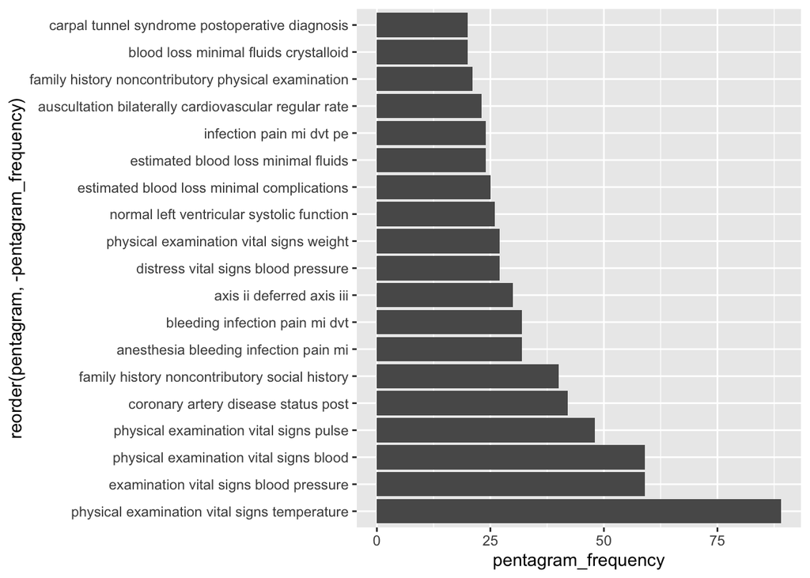

```r
tokens %>%
  filter(!is.na(tokens)) %>%
  ggplot(aes(reorder(pentagram, -pentagram_frequency), pentagram_frequency)) +
  geom_bar(stat = 'identity') +
  coord_flip()
```

# Deliverables

1. Questions 1-7 answered, pdf or html output uploaded to quercus